# analysis

Mikey Elmers

12/06/2022

## Overview

This document investigates the influence of pause-internal particles (PINTs) for university lectures in a content-based listening task that used sythesized speech. The following PINTs are investigated in the present study: silence, inhalation noises, exhalation noises, filler particles, and tongue clicks. Participants were asked to listen to audio recordings that were approximately three minutes in length and answer content-based questions. 180 participants were recruited. 90 participants were monolingual speakers of English. The other 90 participants were native speakers of German with an English proficiency. Half of participants were told in the instructions that they heard computer-generated speech, while the other half were told that the speaker was using a non-ideal microphone and included some background noise. 5 participants were removed due to hearing impairment.

Listeners heard a total of four audio segments, each followed by two questions. Participants were scored based on how many questions they got correct with a maximum possible score of 8. Participants were split into six different groups based upon the condition of the audio. Each participant heard only one condition. The following conditions are investigated:

- base condition which included unmodified synthesized audio and participants were told the audio was from a poor quality microphone
- base_cg condition which included unmodified synthesized audio and participants were told the audio was computer_generated
- sil condition where all non-silence PINTs material is replaced with silence (same total duration as original audio) and participants were told the audio was from a poor quality microphone
- sil_cg condition where all non-silence PINTs material is replaced with silence (same total duration as original audio) and participants were told the audio was computer_generated
- nopints condition where all PINTs are excised from the audio (shorter duration than base and sil conditions) and participants were told the audio was from a poor quality microphone
- nopints_cg condition where all PINTs are excised from the audio (shorter duration than base and sil conditions) and participants were told the audio was computer_generated

### Yale lectures

Lectures taken from [Open Yale Courses](https://oyc.yale.edu).

1. [Langdon Hammer](https://oyc.yale.edu/english/engl-310)
   - Course Number: ENGL 310
   - Course Name: Modern Poetry
   - Sessions: 25

## Dataframe codebook

| Variable Name | Description |
| --- | --- |
| id | subject id number |
| condition | six possible experimental conditions (base, base_cg, sil, sil_cg, nopints, nopints_cg) |
| total_score | subject’s total number of correct answers (max score is 8) |
| age | subject’s age (in years) |
| ease | how easy or difficult the subject found the speaker (1: very difficult to 5: very easy) |
| edu | subject education with 3 levels (high school/equivalent, university, and other) |
| imphear | subject self-assessment of hearing impairment |
| interest | how interesting the subject found the speaker (1: very uninteresting to 5: very interesting) |
| L1 | subject’s native language with 2 levels (English or German) |
| notes | subject self-assessment of whether they took notes (they were instructed to not take notes) |
| prep | how prepared the subject perceived the speaker (1: very unprepared to 5: very prepared) |
| self | subject’s self-assessment of their English proficiency (applicable for the German speakers) |
| test | CEFR test for subject (applicable for the German speakers) |
| question | refers to question 1 or question 2 for each audio file |
| answer | subject’s answer to specific question |
| score | subject’s score; 1 for correct and 0 for incorrect |
| precede | refers to whether PINTs immediately preceded the experimental material |

## Load in data

```r
# remove participant with hearing impairment
df <- df %>% filter(imphear == "no")
df_en <- df_en %>% filter(imphear == "no")
df_de <- df_de %>% filter(imphear == "no")
df_binomial_all <- df_binomial_all %>% filter(imphear == "no")
```

Add column that groups conditions (sil + sil_cg, base + base_cg, etc.)

```r
df <- df %>%
  mutate(group = case_when(
    condition %in% c("sil", "sil_cg") ~ "sil",
    condition %in% c("nopints", "nopints_cg") ~ "nopints",
    TRUE ~ "base"
  ))
```

Add column that groups based on instructions (computer-generated or not)

```r
df <- df %>%
  mutate(cg = case_when(
    condition %in% c("base_cg", "sil_cg", "nopints_cg") ~ "yes",
    condition %in% c("base", "sil", "nopints") ~ "no",
  ))

df_binomial_all <- df_binomial_all %>%
  mutate(cg = case_when(
    condition %in% c("base_cg", "sil_cg", "nopints_cg") ~ "yes",
    condition %in% c("base", "sil", "nopints") ~ "no",
  ))

df_de <- df_de %>%
  mutate(cg = case_when(
    condition %in% c("base_cg", "sil_cg", "nopints_cg") ~ "yes",
    condition %in% c("base", "sil", "nopints") ~ "no",
  ))

df_en <- df_en %>%
  mutate(cg = case_when(
    condition %in% c("base_cg", "sil_cg", "nopints_cg") ~ "yes",
    condition %in% c("base", "sil", "nopints") ~ "no",
  ))
```

### Correlation

```r
df_cor <- df[, c(3,4,5,8,11)]
cor(df_cor)
```

```
##             total_score        age       ease  interest       prep
## total_score  1.00000000 0.19984036 0.15212294 0.3275072 0.09781359
## age          0.19984036 1.00000000 0.06857637 0.1954802 0.07970556
## ease         0.15212294 0.06857637 1.00000000 0.3453168 0.31752644
## interest     0.32750724 0.19548016 0.34531680 1.0000000 0.39216941
## prep         0.09781359 0.07970556 0.31752644 0.3921694 1.00000000
```

```r
cor.test(df_cor$total_score, df_cor$interest)
```

```
##
##  Pearson's product-moment correlation
##
## data:  df_cor$total_score and df_cor$interest
## t = 4.5591, df = 173, p-value = 9.685e-06
## alternative hypothesis: true correlation is not equal to 0
## 95 percent confidence interval:
##  0.1883130 0.4538031
## sample estimates:
##       cor
## 0.3275072
```

```r
cor.test(df_cor$total_score, df_cor$age)
```

```
##
##  Pearson's product-moment correlation
##
## data:  df_cor$total_score and df_cor$age
## t = 2.6826, df = 173, p-value = 0.008014
## alternative hypothesis: true correlation is not equal to 0
## 95 percent confidence interval:
##  0.05307051 0.33815879
## sample estimates:
##       cor
## 0.1998404
```

```r
cor.test(df_cor$total_score, df_cor$ease)
```

```
##
##  Pearson's product-moment correlation
##
## data:  df_cor$total_score and df_cor$ease
## t = 2.0244, df = 173, p-value = 0.04446
## alternative hypothesis: true correlation is not equal to 0
## 95 percent confidence interval:
##  0.003867082 0.293835265
## sample estimates:
##       cor
## 0.1521229
```

```r
cor.test(df_cor$total_score, df_cor$prep)
```

```
##
##  Pearson's product-moment correlation
##
## data:  df_cor$total_score and df_cor$prep
## t = 1.2927, df = 173, p-value = 0.1978
## alternative hypothesis: true correlation is not equal to 0
## 95 percent confidence interval:
##  -0.05127351  0.24263608
## sample estimates:
##        cor
## 0.09781359
```

```r
#test <- cor(df_cor, method = "pearson")
#cor(df_cor, method = "spearman")

df_de_cor <- df_de[, c(3,4,5,8,11)]
cor(df_de_cor)
```

```
##              total_score        age       ease  interest         prep
## total_score  1.000000000 0.15055642 0.07097516 0.2530732 -0.003659475
## age          0.150556421 1.00000000 0.07406654 0.1233812  0.042586920
## ease         0.070975158 0.07406654 1.00000000 0.4466313  0.345403627
## interest     0.253073161 0.12338116 0.44663130 1.0000000  0.317488270
## prep        -0.003659475 0.04258692 0.34540363 0.3174883  1.000000000
```

```r
df_en_cor <- df_en[, c(3,4,5,8,11)]
cor(df_en_cor)
```

```
##             total_score         age        ease  interest      prep
## total_score   1.0000000 0.298404882 0.243711049 0.3948519 0.1947647
## age           0.2984049 1.000000000 0.002202295 0.2804430 0.1334246
## ease          0.2437110 0.002202295 1.000000000 0.2816074 0.3113643
## interest      0.3948519 0.280443002 0.281607407 1.0000000 0.4619039
## prep          0.1947647 0.133424573 0.311364303 0.4619039 1.0000000
```

### Interest

```r
# interest score in general
df %>%
  summarize(mean_int = mean(interest),
            median_int = median(interest),
            sd_int = sd(interest))
```

```
##   mean_int median_int   sd_int
## 1 2.731429          3 1.175363
```

```r
# interest per condition
df %>%
  group_by(condition) %>%
  summarize(mean_int = mean(interest),
            sd_int = sd(interest)) %>%
  arrange(desc(mean_int)) %>%
  ungroup()
```

```
## # A tibble: 6 × 3
##   condition  mean_int sd_int
##   <chr>         <dbl>  <dbl>
## 1 nopints        3.25   1.17
## 2 sil            2.9    1.03
## 3 sil_cg         2.77   1.09
## 4 base_cg        2.64   1.16
## 5 nopints_cg     2.59   1.18
## 6 base           2.24   1.27
```

```r
# interest per L1
df %>%
  group_by(L1) %>%
  summarize(mean_int = mean(interest),
            sd_int = sd(interest)) %>%
  arrange(desc(mean_int)) %>%
  ungroup()
```

```
## # A tibble: 2 × 3
##   L1    mean_int sd_int
##   <chr>    <dbl>  <dbl>
## 1 ger       2.76   1.13
## 2 eng       2.70   1.22
```

```r
# interest grouped by condition and L1
df %>%
  group_by(condition, L1) %>%
  summarize(mean_int = mean(interest)) %>%
  arrange(desc(mean_int)) %>%
  ungroup()
```

```
## # A tibble: 12 × 3
##    condition  L1    mean_int
##    <chr>      <chr>    <dbl>
##  1 nopints    ger       3.36
##  2 nopints    eng       3.14
##  3 sil        ger       3.12
##  4 sil_cg     ger       2.93
##  5 base_cg    eng       2.71
##  6 nopints_cg eng       2.64
##  7 sil        eng       2.64
##  8 sil_cg     eng       2.62
##  9 base_cg    ger       2.57
## 10 nopints_cg ger       2.53
## 11 base       eng       2.47
## 12 base       ger       2
```

```r
######################### L1 Comparison ########################################
# normality is violated
# H0: The samples come from a normal distribution
# H1: The samples do not come from a normal distribution
# p-value < 0.05 (data deviates from normality)
shapiro.test(df$interest)
```

```
##
##  Shapiro-Wilk normality test
##
## data:  df$interest
## W = 0.90916, p-value = 6.281e-09
```

```r
# homogeneity of variances is maintained across L1
# H0: variances are equal
# H1: variances are not equal
# p-value > 0.05 (variances are not significantly different between groups)
leveneTest(interest ~ L1, data = df)
```

```
## Levene's Test for Homogeneity of Variance (center = median)
##        Df F value Pr(>F)
## group   1  1.0525 0.3064
##       173
```

```r
leveneTest(interest ~ condition, data = df)
```

```
## Levene's Test for Homogeneity of Variance (center = median)
##        Df F value Pr(>F)
## group   5  0.5261 0.7563
##       169
```

```r
# t-test
# since the central limit theorem is satisfied (n > 30) we will still proceed with parametric tests.
t.test(df_en$interest, df_de$interest, var.equal = TRUE)
```

```
##
##  Two Sample t-test
##
## data:  df_en$interest and df_de$interest
## t = -0.33799, df = 173, p-value = 0.7358
## alternative hypothesis: true difference in means is not equal to 0
## 95 percent confidence interval:
##  -0.4118516  0.2914232
## sample estimates:
## mean of x mean of y
##  2.701149  2.761364
```

```r
# cohen's d
cohen.d(df_en$interest, df_de$interest)
```

```
##
## Cohen's d
##
## d estimate: -0.05109975 (negligible)
## 95 percent confidence interval:
##      lower      upper
## -0.3495595  0.2473600
```

```r
######################### Condition Comparison #################################
# anova for each condition
summary(aov(interest ~ condition, data = df))
```

```
##              Df Sum Sq Mean Sq F value Pr(>F)
## condition     5  16.23   3.247   2.448 0.0359 *
## Residuals   169 224.14   1.326
## ---
## Signif. codes:  0 '***' 0.001 '**' 0.01 '*' 0.05 '.' 0.1 ' ' 1
```

```r
# Bonferroni-correct t-test
pairwise.t.test(df$interest, df$condition, p.adjust.method = "bonferroni")
```

```
##
##  Pairwise comparisons using t tests with pooled SD
##
## data:  df$interest and df$condition
##
##            base  base_cg nopints nopints_cg sil
## base_cg    1.000 -       -       -          -
## nopints    0.017 0.753   -       -          -
## nopints_cg 1.000 1.000   0.465   -          -
## sil        0.442 1.000   1.000   1.000      -
## sil_cg     1.000 1.000   1.000   1.000      1.000
##
## P value adjustment method: bonferroni
```

Converting variables to factors.

```r
# convert to factors
df$id <- as.factor(df$id)
df$condition <- as.factor(df$condition)
df$group <- as.factor(df$group)
df$cg <- as.factor(df$cg)
# df$ease <- as.factor(df$ease)
df$prep <- as.factor(df$prep)
df$edu <- as.factor(df$edu)
df$L1 <- as.factor(df$L1)
df$self <- as.factor(df$self)
df$test <- as.factor(df$test)

df_de$id <- as.factor(df_de$id)
df_de$condition <- as.factor(df_de$condition)
df_de$cg <- as.factor(df_de$cg)
# df_de$ease <- as.factor(df_de$ease)
df_de$prep <- as.factor(df_de$prep)
df_de$edu <- as.factor(df_de$edu)
df_de$L1 <- as.factor(df_de$L1)
df_de$self <- as.factor(df_de$self)
df_de$test <- as.factor(df_de$test)

df_en$id <- as.factor(df_en$id)
df_en$condition <- as.factor(df_en$condition)
df_en$cg <- as.factor(df_en$cg)
# df_en$ease <- as.factor(df_en$ease)
df_en$prep <- as.factor(df_en$prep)
df_en$edu <- as.factor(df_en$edu)
df_en$L1 <- as.factor(df_en$L1)
df_en$self <- as.factor(df_en$self)
df_en$test <- as.factor(df_en$test)

df_binomial_all$id <- as.factor(df_binomial_all$id)
df_binomial_all$condition <- as.factor(df_binomial_all$condition)
df_binomial_all$cg <- as.factor(df_binomial_all$cg)
# df_binomial_all$ease <- as.factor(df_binomial_all$ease)
df_binomial_all$prep <- as.factor(df_binomial_all$prep)
df_binomial_all$edu <- as.factor(df_binomial_all$edu)
df_binomial_all$L1 <- as.factor(df_binomial_all$L1)
df_binomial_all$self <- as.factor(df_binomial_all$self)
df_binomial_all$test <- as.factor(df_binomial_all$test)
df_binomial_all$question <- as.factor(df_binomial_all$question)
df_binomial_all$precede <- as.factor(df_binomial_all$precede)
```

## Descriptive Statistics

### All participants

The mean, median, standard deviation and number are found below. The maximum score is 8.

```r
df %>%
  summarize(mean_all = mean(total_score),
            median_all = median(total_score),
            sd_all = sd(total_score),
            N = n())
```

```
##   mean_all median_all   sd_all   N
## 1     5.44          5 1.652445 175
```

### L1 comparison

On average the L1 English listeners performed worse as seen by the mean with a comparable variance. However, the difference between means is not statistically significant between the two groups.

```r
df %>%
  group_by(L1) %>%
  summarize(mean = mean(total_score),
            median = median(total_score),
            sd = sd(total_score),
            N = n()) %>%
  ungroup()
```

```
## # A tibble: 2 × 5
##   L1     mean median    sd     N
##   <fct> <dbl>  <dbl> <dbl> <int>
## 1 eng    5.31      5  1.67    87
## 2 ger    5.57      6  1.64    88
```

```r
# normality is violated
# H0: The samples come from a normal distribution
# H1: The samples do not come from a normal distribution
# p-value < 0.05 (data deviates from normality)
shapiro.test(df$total_score)
```

```
##
##  Shapiro-Wilk normality test
##
## data:  df$total_score
## W = 0.9439, p-value = 2.212e-06
```

```r
# homogeneity of variances is maintained across L1
# H0: variances are equal
# H1: variances are not equal
# p-value > 0.05 (variances are not significantly different between groups)
leveneTest(total_score ~ L1, data = df)
```

```
## Levene's Test for Homogeneity of Variance (center = median)
##        Df F value Pr(>F)
## group   1   8e-04 0.9778
##       173
```

```r
# t-test
# since the central limit theorem is satisfied (n > 30) we will still proceed with parametric tests.
t.test(df_en$total_score, df_de$total_score, var.equal = TRUE)
```

```
##
##  Two Sample t-test
##
## data:  df_en$total_score and df_de$total_score
## t = -1.0322, df = 173, p-value = 0.3034
## alternative hypothesis: true difference in means is not equal to 0
## 95 percent confidence interval:
##  -0.7508520  0.2351781
## sample estimates:
## mean of x mean of y
##  5.310345  5.568182
```

```r
# cohen's d
cohen.d(df_en$total_score, df_de$total_score)
```

```
##
## Cohen's d
##
## d estimate: -0.156063 (negligible)
## 95 percent confidence interval:
##      lower      upper
## -0.4549279  0.1428019
```

### Condition & Group comparison

The condition with the highest mean is the silence condition where participants were told the audio was computer-generated. The conditions where the participants were told the audio was computer-generated was rated higher than the conditions where they were told the speaker used a poor quality microphone, except for the no PINTs condition. However, none of the groups or conditions total score means were statistically different from each other. We used a Bonferroni-corrected pairwise t-test to compare the mean total scores. The results indicated that there were no significant differents between any of the mean total scores. However, this method is conversative and struggles when there are many groups being compared. A t-test between the silence and silence_cg shows a significant difference between the means of the total scores.

```r
df %>%
  group_by(condition) %>%
  summarize(mean = mean(total_score),
            median = median(total_score),
            sd = sd(total_score),
            N = n()) %>%
  arrange(desc(mean)) %>%
  ungroup()
```

```
## # A tibble: 6 × 5
##   condition   mean median    sd     N
##   <fct>      <dbl>  <dbl> <dbl> <int>
## 1 sil_cg      5.77      5  1.41    31
## 2 nopints     5.71      6  1.61    28
## 3 base_cg     5.61      6  1.64    28
## 4 base        5.45      5  1.78    29
## 5 nopints_cg  5.34      5  1.72    29
## 6 sil         4.77      5  1.68    30
```

```r
# normality is violated
# H0: The samples come from a normal distribution
# H1: The samples do not come from a normal distribution
# p-value < 0.05 (data deviates from normality)
shapiro.test(df$total_score)
```

```
##
##  Shapiro-Wilk normality test
##
## data:  df$total_score
## W = 0.9439, p-value = 2.212e-06
```

```r
# homogeneity of variances is maintained across conditions
# H0: variances are equal
# H1: variances are not equal
# p-value > 0.05 (variances are not significantly different between groups)
leveneTest(total_score ~ condition, data = df)
```

```
## Levene's Test for Homogeneity of Variance (center = median)
##        Df F value Pr(>F)
## group   5  0.3963 0.8509
##       169
```

```r
leveneTest(total_score ~ group, data = df)
```

```
## Levene's Test for Homogeneity of Variance (center = median)
##        Df F value Pr(>F)
## group   2  0.4905 0.6132
##       172
```

```r
# anova for each group
summary(aov(total_score ~ group, data = df))
```

```
##              Df Sum Sq Mean Sq F value Pr(>F)
## group         2    2.4   1.218   0.443  0.643
## Residuals   172  472.7   2.748
```

```r
# Bonferroni-correct t-test
pairwise.t.test(df$total_score, df$group, p.adjust.method = "bonferroni")
```

```
##
##  Pairwise comparisons using t tests with pooled SD
##
## data:  df$total_score and df$group
##
##         base nopints
## nopints 1    -
## sil     1    1
##
## P value adjustment method: bonferroni
```

```r
# anova for each condition
summary(aov(total_score ~ condition, data = df))
```

```
##              Df Sum Sq Mean Sq F value Pr(>F)
## condition     5   20.2   4.043   1.502  0.192
## Residuals   169  454.9   2.692
```

```r
# Bonferroni-correct t-test
pairwise.t.test(df$total_score, df$condition, p.adjust.method = "bonferroni")
```

```
##
##  Pairwise comparisons using t tests with pooled SD
##
## data:  df$total_score and df$condition
##
##            base base_cg nopints nopints_cg sil
## base_cg    1.00 -       -       -          -
## nopints    1.00 1.00    -       -          -
## nopints_cg 1.00 1.00    1.00    -          -
## sil        1.00 0.79    0.44    1.00       -
## sil_cg     1.00 1.00    1.00    1.00       0.26
##
## P value adjustment method: bonferroni
```

```r
# t test
# since the central limit theorem is satisfied (n > 30) we will still proceed with parametric tests.
sil_cg_group <- subset(df, condition == "sil_cg")
sil_group <- subset(df, condition == "sil")
t.test(sil_cg_group$total_score, sil_group$total_score, var.equal = TRUE)
```

```
##
##  Two Sample t-test
##
## data:  sil_cg_group$total_score and sil_group$total_score
## t = 2.5467, df = 59, p-value = 0.0135
## alternative hypothesis: true difference in means is not equal to 0
## 95 percent confidence interval:
##  0.215895 1.799159
## sample estimates:
## mean of x mean of y
##  5.774194  4.766667
```

```r
# cohen's d
cohen.d(sil_cg_group$total_score, sil_group$total_score)
```

```
##
## Cohen's d
##
## d estimate: 0.6522332 (medium)
## 95 percent confidence interval:
##     lower     upper
## 0.1263163 1.1781500
```

### Condition and L1 comparison

```r
df %>%
  group_by(condition, L1) %>%
  summarize(mean = mean(total_score),
            median = median(total_score),
            sd = sd(total_score),
            N = n()) %>%
  arrange(desc(mean)) %>%
  ungroup()
```

```
## # A tibble: 12 × 6
##    condition  L1     mean median    sd     N
##    <fct>      <fct> <dbl>  <dbl> <dbl> <int>
##  1 sil_cg     ger    5.8     5    1.01    15
##  2 base_cg    ger    5.79    6    1.85    14
##  3 nopints    ger    5.79    6.5  1.97    14
##  4 sil_cg     eng    5.75    6    1.73    16
##  5 nopints_cg ger    5.73    6    1.58    15
##  6 nopints    eng    5.64    6    1.22    14
##  7 base       eng    5.53    5    1.85    15
##  8 base_cg    eng    5.43    5.5  1.45    14
##  9 base       ger    5.36    5.5  1.78    14
## 10 sil        ger    5       5    1.63    16
## 11 nopints_cg eng    4.93    4.5  1.82    14
## 12 sil        eng    4.5     4.5  1.74    14
```

### CG

```r
df %>%
  group_by(cg) %>%
  summarize(mean = mean(total_score),
            median = median(total_score),
            sd = sd(total_score),
            N = n()) %>%
  ungroup()
```

```
## # A tibble: 2 × 5
##   cg     mean median    sd     N
##   <fct> <dbl>  <dbl> <dbl> <int>
## 1 no     5.30      5  1.72    87
## 2 yes    5.58      5  1.58    88
```

```r
# normality is violated
# H0: The samples come from a normal distribution
# H1: The samples do not come from a normal distribution
# p-value < 0.05 (data deviates from normality)
shapiro.test(df$total_score)
```

```
##
##  Shapiro-Wilk normality test
##
## data:  df$total_score
## W = 0.9439, p-value = 2.212e-06
```

```r
# homogeneity of variances is maintained across L1
# H0: variances are equal
# H1: variances are not equal
# p-value > 0.05 (variances are not significantly different between groups)
leveneTest(total_score ~ cg, data = df)
```

```
## Levene's Test for Homogeneity of Variance (center = median)
##        Df F value Pr(>F)
## group   1  0.3926 0.5318
##       173
```

```r
# t-test
# since the central limit theorem is satisfied (n > 30) we will still proceed with parametric tests.
cg_yes <- subset(df, cg == "yes")
cg_no <- subset(df, cg == "no")
t.test(cg_yes$total_score, cg_no$total_score, var.equal = TRUE)
```

```
##
##  Two Sample t-test
##
## data:  cg_yes$total_score and cg_no$total_score
## t = 1.1244, df = 173, p-value = 0.2624
## alternative hypothesis: true difference in means is not equal to 0
## 95 percent confidence interval:
##  -0.2120390  0.7734287
## sample estimates:
## mean of x mean of y
##  5.579545  5.298851
```

```r
# cohen's d
cohen.d(cg_yes$total_score, cg_no$total_score)
```

```
##
## Cohen's d
##
## d estimate: 0.1699953 (negligible)
## 95 percent confidence interval:
##      lower      upper
## -0.1289542  0.4689449
```

### L1 and CG

```r
df %>%
  group_by(L1, cg) %>%
  summarize(mean = mean(total_score),
            median = median(total_score),
            sd = sd(total_score),
            N = n()) %>%
  arrange(desc(mean)) %>%
  ungroup()
```

[output not shown]

```
## # A tibble: 4 × 6
##   L1    cg     mean median    sd     N
##   <fct> <fct> <dbl>  <dbl> <dbl> <int>
## 1 ger   yes    5.77    6    1.48    44
## 2 eng   yes    5.39    5    1.67    44
## 3 ger   no     5.36    5.5  1.78    44
## 4 eng   no     5.23    5    1.67    43
```

```r
summary(aov(total_score ~ L1 + cg, data = df))
```

```
##              Df Sum Sq Mean Sq F value Pr(>F)
## L1            1    2.9   2.908   1.067  0.303
## cg            1    3.5   3.484   1.278  0.260
## Residuals   172  468.7   2.725
```

```r
summary(aov(total_score ~ L1, data = df))
```

```
##              Df Sum Sq Mean Sq F value Pr(>F)
## L1            1    2.9   2.908   1.066  0.303
## Residuals   173  472.2   2.729
```

```r
summary(aov(total_score ~ cg, data = df))
```

```
##              Df Sum Sq Mean Sq F value Pr(>F)
## cg            1    3.4   3.447   1.264  0.262
## Residuals   173  471.7   2.726
```

### Precede

Subject’s performed better when experimental material was not immediately preceded by PINTs material. The output from the Wilcoxon rank-sum test indicates that there is evidence for difference between the two groups.

```r
df_binomial_all %>%
  group_by(precede) %>%
  summarize(mean = mean(score),
            median = median(score),
            sd = sd(score),
            count = sum(score == 1),
            N = n()) %>%
  arrange(desc(mean)) %>%
  ungroup()
```

```
## # A tibble: 2 × 6
##   precede  mean median    sd count     N
##   <fct>   <dbl>  <dbl> <dbl> <int> <int>
## 1 no      0.769      1 0.422   363   472
## 2 yes     0.581      1 0.494   274   472
```

```r
# normality is violated
# H0: The samples come from a normal distribution
# H1: The samples do not come from a normal distribution
# p-value < 0.05 (data deviates from normality)
shapiro.test(df_binomial_all$score)
```

```
##
##  Shapiro-Wilk normality test
##
## data:  df_binomial_all$score
## W = 0.59055, p-value < 2.2e-16
```

```r
# homogeneity of variances is maintained across L1
# H0: variances are equal
# H1: variances are not equal
# p-value < 0.05 (variances are significantly different between groups)
leveneTest(score ~ precede, data = df_binomial_all)
```

```
## Levene's Test for Homogeneity of Variance (center = median)
##        Df F value    Pr(>F)
## group   1  39.766 4.395e-10 ***
##       942
## ---
## Signif. codes:  0 '***' 0.001 '**' 0.01 '*' 0.05 '.' 0.1 ' ' 1
```

```r
# Wilcoxon rank-sum test
# since both normality and equal variances is violated a non-parametric test is used
precede_yes_group <- subset(df_binomial_all, precede == "yes")
precede_no_group <- subset(df_binomial_all, precede == "no")
wilcox.test(precede_no_group$score, precede_yes_group$score)
```

```
##
##  Wilcoxon rank sum test with continuity correction
##
## data:  precede_no_group$score and precede_yes_group$score
## W = 132396, p-value = 6.405e-10
## alternative hypothesis: true location shift is not equal to 0
```

### Precede - by condition

```r
df_binomial_all %>%
  group_by(precede, condition) %>%
  summarize(mean = mean(score),
            median = median(score),
            sd = sd(score),
            count = sum(score == 1),
            N = n()) %>%
  arrange(desc(mean)) %>%
  ungroup()
```

```
## # A tibble: 8 × 7
##   precede condition  mean median    sd count     N
##   <fct>   <fct>     <dbl>  <dbl> <dbl> <int> <int>
## 1 no      sil_cg    0.863      1 0.345   107   124
## 2 no      base_cg   0.804      1 0.399    90   112
## 3 no      base      0.75       1 0.435    87   116
## 4 no      sil       0.658      1 0.476    79   120
## 5 yes     base      0.612      1 0.489    71   116
## 6 yes     base_cg   0.598      1 0.492    67   112
## 7 yes     sil_cg    0.581      1 0.495    72   124
## 8 yes     sil       0.533      1 0.501    64   120
```

```r
# Kruskal-Wallis rank sum test and Dunn's test for post-hoc comparisons with Bonferroni correction
kruskal.test(score ~ precede, data = df_binomial_all)
```

```
##
##  Kruskal-Wallis rank sum test
##
## data:  score by precede
## Kruskal-Wallis chi-squared = 38.196, df = 1, p-value = 6.399e-10
```

```r
kruskal.test(score ~ condition, data = df_binomial_all)
```

```
##
##  Kruskal-Wallis rank sum test
##
## data:  score by condition
## Kruskal-Wallis chi-squared = 10.039, df = 3, p-value = 0.01824
```

```r
dunn.test(df_binomial_all$score, df_binomial_all$condition, method = "bonferroni")
```

```
##   Kruskal-Wallis rank sum test
##
## data: x and group
## Kruskal-Wallis chi-squared = 10.0388, df = 3, p-value = 0.02
##
##
##                            Comparison of x by group
##                                  (Bonferroni)
## Col Mean-|
## Row Mean |       base    base_cg        sil
## ---------+---------------------------------
##  base_cg |  -0.452305
##          |     1.0000
##      sil |   1.974363   2.412731
##          |     0.1450     0.0475
##   sil_cg |  -0.951634  -0.483325  -2.967502
##          |     1.0000     1.0000    0.0090*
##
## alpha = 0.05
## Reject Ho if p <= alpha/2
```

## Inferential Statistics

### Checking assumption

The shapiro test indicates that our data does not come a normal distribution. Since the central limit theorem is satisfied (n > 30) we will still proceed with parametric tests.

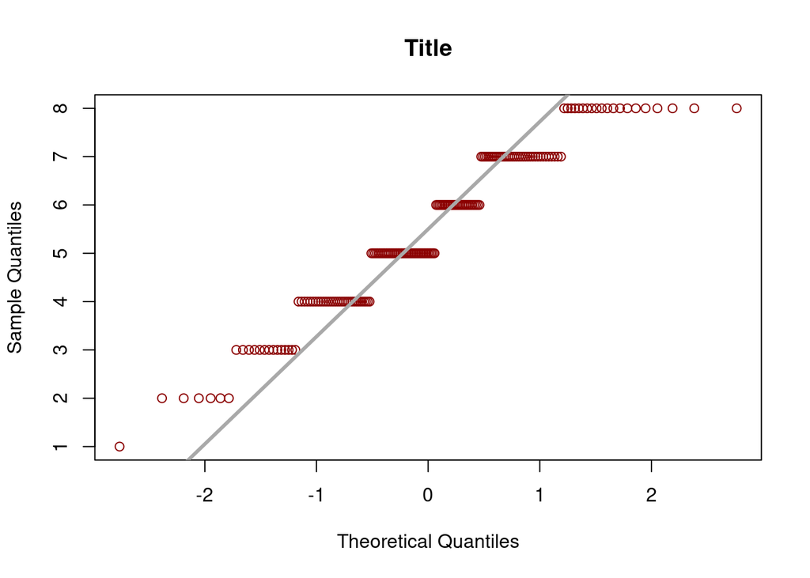

```r
# Checking Assumptions
qqnorm(df$total_score, col = "darkred", main = "Title")
qqline(df$total_score, col = "darkgrey", lwd = 3)
```

```r
# H0: The samples come from a normal distribution
# H1: The samples do not come from a normal distribution
# p-value < .05.Data deviates from normality
shapiro.test(df$total_score)
```

```
##
##  Shapiro-Wilk normality test
##
## data:  df$total_score
## W = 0.9439, p-value = 2.212e-06
```

## Modeling

### All Data: linear regression with interest

```r
#model_test <- lmer(total_score ~ condition + (1 | id), data = df, REML = FALSE)
df$interest <- as.factor(df$interest)
df$ease <- as.factor(df$ease)
model0 <- lm(total_score ~ interest, data = df)
model1 <- lm(total_score ~ interest + ease, data = df)
model2 <- lm(total_score ~ interest * ease, data = df)
model3 <- lm(total_score ~ interest + L1, data = df)
model4 <- lm(total_score ~ interest * L1, data = df)
model5 <- lm(total_score ~ interest + condition, data = df)
model6 <- lm(total_score ~ interest * condition, data = df)
model7 <- lm(total_score ~ interest + group, data = df)
model8 <- lm(total_score ~ interest * group, data = df)
model9 <- lm(total_score ~ interest + cg, data = df)
AIC(model0, model1, model2, model3, model4, model5, model6, model7, model8, model9)
```

```
##        df      AIC
## model0  6 658.4852
## model1 10 663.6015
## model2 20 671.0799
## model3  7 659.0272
## model4 11 666.0763
## model5 11 659.6829
## model6 31 677.9564
## model7  8 660.8868
## model8 16 668.1990
## model9  7 657.8712
```

```r
summary(model0)
```

```
##
## Call:
## lm(formula = total_score ~ interest, data = df)
##
## Residuals:
##     Min      1Q  Median      3Q     Max
## -4.3333 -1.0465  0.0526  1.0732  3.0938
##
## Coefficients:
##             Estimate Std. Error t value Pr(>|t|)
## (Intercept)   4.9063     0.2752  17.827  < 2e-16 ***
## interest2     0.1403     0.3635   0.386  0.70005
## interest3     0.4271     0.3511   1.216  0.22550
## interest4     1.0411     0.3735   2.787  0.00592 **
## interest5     2.3665     0.5441   4.349 2.35e-05 ***
## ---
## Signif. codes:  0 '***' 0.001 '**' 0.01 '*' 0.05 '.' 0.1 ' ' 1
##
## Residual standard error: 1.557 on 170 degrees of freedom
## Multiple R-squared:  0.1328, Adjusted R-squared:  0.1124
## F-statistic: 6.507 on 4 and 170 DF,  p-value: 6.77e-05
```

```r
summary(model9)
```

```
##
## Call:
## lm(formula = total_score ~ interest + cg, data = df)
##
## Residuals:
##     Min      1Q  Median      3Q     Max
## -4.1448 -1.1348 -0.0938  1.2303  3.2813
##
## Coefficients:
##             Estimate Std. Error t value Pr(>|t|)
## (Intercept)   4.7187     0.2981  15.827  < 2e-16 ***
## interest2     0.1272     0.3619   0.351  0.72573
## interest3     0.4161     0.3496   1.190  0.23566
## interest4     1.0510     0.3719   2.826  0.00528 **
## interest5     2.4176     0.5426   4.455 1.52e-05 ***
## cgyes         0.3751     0.2352   1.595  0.11264
## ---
## Signif. codes:  0 '***' 0.001 '**' 0.01 '*' 0.05 '.' 0.1 ' ' 1
##
## Residual standard error: 1.55 on 169 degrees of freedom
## Multiple R-squared:  0.1456, Adjusted R-squared:  0.1204
## F-statistic: 5.761 on 5 and 169 DF,  p-value: 6.151e-05
```

```r
#model4 <- lmer(total_score ~ L1 + (1 | condition), data = df, REML = FALSE)
```

### L1 German participants only

```r
df_de$ease <- as.factor(df_de$ease)
df_de$interest <- as.factor(df_de$interest)
model_de0 <- lm(total_score ~ condition, data = df_de)
model_de1 <- lm(total_score ~ ease, data = df_de)
model_de2 <- lm(total_score ~ prep, data = df_de)
model_de3 <- lm(total_score ~ age, data = df_de)
model_de4 <- lm(total_score ~ edu, data = df_de)
model_de5 <- lm(total_score ~ interest, data = df_de)
model_de6 <- lm(total_score ~ self, data = df_de)
model_de7 <- lm(total_score ~ test, data = df_de)

AIC(model_de0, model_de1, model_de2, model_de3, model_de4, model_de5, model_de6,
    model_de7)
```

```
##           df      AIC
## model_de0  7 346.4468
## model_de1  6 344.4557
## model_de2  6 346.2654
## model_de3  3 339.6241
## model_de4  4 343.5853
## model_de5  6 339.3075
## model_de6  4 332.8405
## model_de7  8 341.7337
```

```r
summary(model_de6)
```

```
##
## Call:
## lm(formula = total_score ~ self, data = df_de)
##
## Residuals:
##     Min      1Q  Median      3Q     Max
## -3.4603 -1.1463 -0.0417  1.1037  2.5397
##
## Coefficients:
##             Estimate Std. Error t value Pr(>|t|)
## (Intercept)   5.4603     0.1964  27.799  < 2e-16 ***
## selfbeg      -4.4603     1.5714  -2.838  0.00567 **
## selfint       0.5813     0.3740   1.554  0.12378
## ---
## Signif. codes:  0 '***' 0.001 '**' 0.01 '*' 0.05 '.' 0.1 ' ' 1
##
## Residual standard error: 1.559 on 85 degrees of freedom
## Multiple R-squared:  0.1155, Adjusted R-squared:  0.0947
## F-statistic:  5.55 on 2 and 85 DF,  p-value: 0.005426
```

```r
df_de %>%
  group_by(self) %>%
  count() %>%
  ungroup()
```

```
## # A tibble: 3 × 2
##   self      n
##   <fct> <int>
## 1 adv      63
## 2 beg       1
## 3 int      24
```

```r
summary(model_de5)
```

```
##
## Call:
## lm(formula = total_score ~ interest, data = df_de)
##
## Residuals:
##    Min     1Q Median     3Q    Max
##   -4.5   -1.1   -0.1    1.5    2.9
##
## Coefficients:
##             Estimate Std. Error t value Pr(>|t|)
## (Intercept)   5.2667     0.4131  12.748   <2e-16 ***
## interest2    -0.1667     0.5465  -0.305   0.7612
## interest3     0.2333     0.5120   0.456   0.6497
## interest4     0.7333     0.5409   1.356   0.1789
## interest5     1.9833     0.9004   2.203   0.0304 *
## ---
## Signif. codes:  0 '***' 0.001 '**' 0.01 '*' 0.05 '.' 0.1 ' ' 1
##
## Residual standard error: 1.6 on 83 degrees of freedom
## Multiple R-squared:  0.09036,    Adjusted R-squared:  0.04652
## F-statistic: 2.061 on 4 and 83 DF,  p-value: 0.09327
```

### Monolingual English participants only

```r
df_en$interest <- as.factor(df_en$interest)
df_en$ease <- as.factor(df_en$ease)
model_en0 <- lm(total_score ~ condition, data = df_en)
model_en1 <- lm(total_score ~ ease, data = df_en)
model_en2 <- lm(total_score ~ prep, data = df_en)
model_en3 <- lm(total_score ~ age, data = df_en)
model_en4 <- lm(total_score ~ edu, data = df_en)
model_en5 <- lm(total_score ~ interest, data = df_en)
AIC(model_en0, model_en1, model_en2, model_en3, model_en4, model_en5)
```

```
##           df      AIC
## model_en0  7 342.3177
## model_en1  5 329.3031
## model_en2  6 339.0993
## model_en3  3 332.5616
## model_en4  4 339.3400
## model_en5  6 328.6289
```

```r
summary(model_en5)
```

```
##
## Call:
## lm(formula = total_score ~ interest, data = df_en)
##
## Residuals:
##    Min     1Q Median     3Q    Max
## -3.882 -1.000  0.000  1.000  2.870
##
## Coefficients:
##             Estimate Std. Error t value Pr(>|t|)
## (Intercept)   4.5882     0.3730  12.302  < 2e-16 ***
## interest2     0.4118     0.4919   0.837 0.404941
## interest3     0.5422     0.4919   1.102 0.273541
## interest4     1.2941     0.5275   2.453 0.016268 *
## interest5     2.6975     0.6906   3.906 0.000192 ***
## ---
## Signif. codes:  0 '***' 0.001 '**' 0.01 '*' 0.05 '.' 0.1 ' ' 1
##
## Residual standard error: 1.538 on 82 degrees of freedom
## Multiple R-squared:  0.1873, Adjusted R-squared:  0.1477
## F-statistic: 4.726 on 4 and 82 DF,  p-value: 0.001758
```

### Binomial Data: All

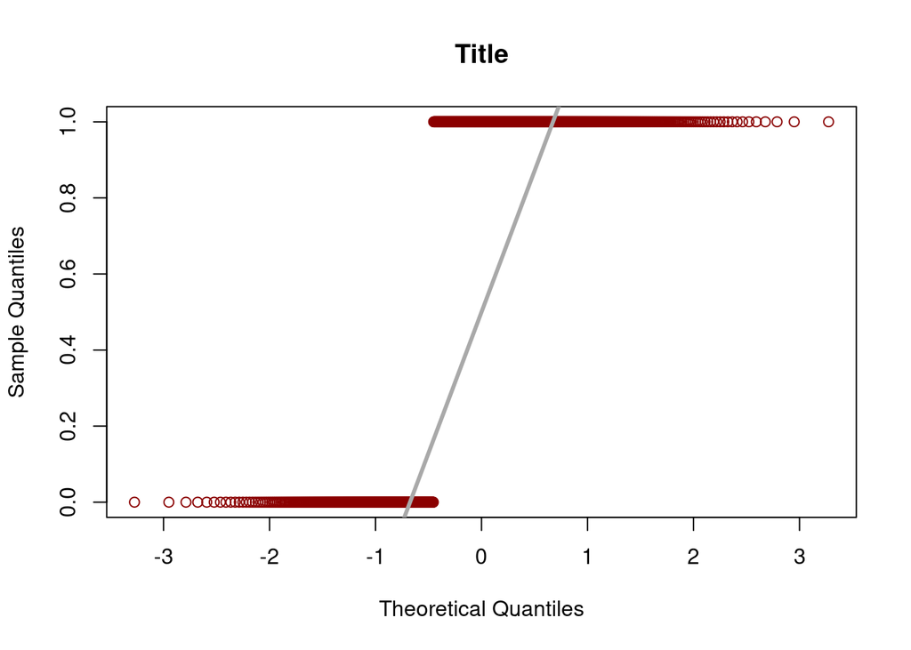

```r
# Checking Assumptions
qqnorm(df_binomial_all$score, col = "darkred", main = "Title")
qqline(df_binomial_all$score, col = "darkgrey", lwd = 3)
```

```r
# H0: The samples come from a normal distribution
# H1: The samples do not come from a normal distribution
# p-value < .05.Data deviates from normality
shapiro.test(df_binomial_all$score)
```

```
##
##  Shapiro-Wilk normality test
##
## data:  df_binomial_all$score
## W = 0.59055, p-value < 2.2e-16
```

```r
df_binomial_all$ease <- as.factor(df_binomial_all$ease)
df_binomial_all$interest <- as.factor(df_binomial_all$interest)
model_binomial0 <- glmer(score ~ L1 + (1 | id), data = df_binomial_all, family = binomial)
model_binomial1 <- glmer(score ~ condition + (1 | id), data = df_binomial_all, family = binomial)
model_binomial2 <- glmer(score ~ precede + (1 | id), data = df_binomial_all, family = binomial)
model_binomial3 <- glmer(score ~ ease + (1 | id), data = df_binomial_all, family = binomial)
model_binomial4 <- glmer(score ~ interest + (1 | id), data = df_binomial_all, family = binomial)
model_binomial5 <- glmer(score ~ age + (1 | id), data = df_binomial_all, family = binomial)
model_binomial6 <- glmer(score ~ precede + interest + (1 | id), data = df_binomial_all, family = binomial)
model_binomial8 <- glmer(score ~ precede + cg + (1 | id), data = df_binomial_all, family = binomial)
model_binomial9 <- glmer(score ~ precede * cg + (1 | id), data = df_binomial_all, family = binomial)
model_binomial10 <- glmer(score ~ cg + (1 | id), data = df_binomial_all, family = binomial)
model_binomial11 <- glmer(score ~ precede + interest + cg + (1 | id), data = df_binomial_all, family = binomial)

AIC(model_binomial0, model_binomial1, model_binomial2, model_binomial3, model_binomial4, model_binomial5,
    model_binomial6, model_binomial8, model_binomial9, model_binomial10, model_binomial11)
```

```
##                  df      AIC
## model_binomial0   3 1181.919
## model_binomial1   5 1179.561
## model_binomial2   3 1140.013
## model_binomial3   5 1181.280
## model_binomial4   6 1169.573
## model_binomial5   3 1179.941
## model_binomial6   7 1129.430
## model_binomial8   4 1138.149
## model_binomial9   5 1134.321
## model_binomial10  3 1178.272
## model_binomial11  8 1127.667
```

```r
summary(model_binomial6)
```

```
## Generalized linear mixed model fit by maximum likelihood (Laplace
##   Approximation) [glmerMod]
##  Family: binomial  ( logit )
## Formula: score ~ precede + interest + (1 | id)
##    Data: df_binomial_all
##
##      AIC      BIC   logLik deviance df.resid
##   1129.4   1163.4   -557.7   1115.4      937
##
## Scaled residuals:
##     Min      1Q  Median      3Q     Max
## -2.4102 -0.9033  0.4566  0.6929  1.3940
##
## Random effects:
##  Groups Name        Variance Std.Dev.
##  id     (Intercept) 0.3237   0.5689
## Number of obs: 944, groups:  id, 118
##
## Fixed effects:
##             Estimate Std. Error z value Pr(>|z|)
## (Intercept)   0.8353     0.2103   3.973 7.10e-05 ***
## precedeyes   -0.9635     0.1520  -6.338 2.33e-10 ***
## interest2     0.3755     0.2671   1.406 0.159700
## interest3     0.4177     0.2504   1.668 0.095223 .
## interest4     0.9787     0.2965   3.301 0.000964 ***
## interest5     1.7983     0.5457   3.295 0.000984 ***
## ---
## Signif. codes:  0 '***' 0.001 '**' 0.01 '*' 0.05 '.' 0.1 ' ' 1
##
## Correlation of Fixed Effects:
##            (Intr) prcdys intrs2 intrs3 intrs4
## precedeyes -0.391
## interest2  -0.655 -0.025
## interest3  -0.697 -0.030  0.562
## interest4  -0.576 -0.054  0.476  0.509
## interest5  -0.304 -0.049  0.261  0.279  0.240
```

```r
summary(model_binomial11)
```

```
## Generalized linear mixed model fit by maximum likelihood (Laplace
##   Approximation) [glmerMod]
##  Family: binomial  ( logit )
## Formula: score ~ precede + interest + cg + (1 | id)
##    Data: df_binomial_all
##
##      AIC      BIC   logLik deviance df.resid
##   1127.7   1166.5   -555.8   1111.7      936
##
## Scaled residuals:
##     Min      1Q  Median      3Q     Max
## -2.5693 -0.9417  0.4417  0.6697  1.4360
##
## Random effects:
##  Groups Name        Variance Std.Dev.
##  id     (Intercept) 0.2894   0.538
## Number of obs: 944, groups:  id, 118
##
## Fixed effects:
##             Estimate Std. Error z value Pr(>|z|)
## (Intercept)   0.6863     0.2187   3.138  0.00170 **
## precedeyes   -0.9630     0.1520  -6.334 2.38e-10 ***
## interest2     0.3495     0.2622   1.333  0.18256
## interest3     0.3727     0.2464   1.512  0.13042
## interest4     0.9464     0.2912   3.250  0.00115 **
## interest5     1.7650     0.5387   3.276  0.00105 **
## cgyes         0.3522     0.1801   1.955  0.05055 .
## ---
## Signif. codes:  0 '***' 0.001 '**' 0.01 '*' 0.05 '.' 0.1 ' ' 1
##
## Correlation of Fixed Effects:
##            (Intr) prcdys intrs2 intrs3 intrs4 intrs5
## precedeyes -0.366
## interest2  -0.601 -0.024
## interest3  -0.625 -0.028  0.561
## interest4  -0.528 -0.053  0.476  0.508
## interest5  -0.280 -0.048  0.259  0.276  0.237
## cgyes      -0.329 -0.030 -0.042 -0.083 -0.038 -0.012
```

```r
# anova
df_aov <- aov(total_score ~ condition,
              data = df)

shapiro.test(df_aov$residuals)
```

```
##
##  Shapiro-Wilk normality test
##
## data:  df_aov$residuals
## W = 0.97465, p-value = 0.002757
```

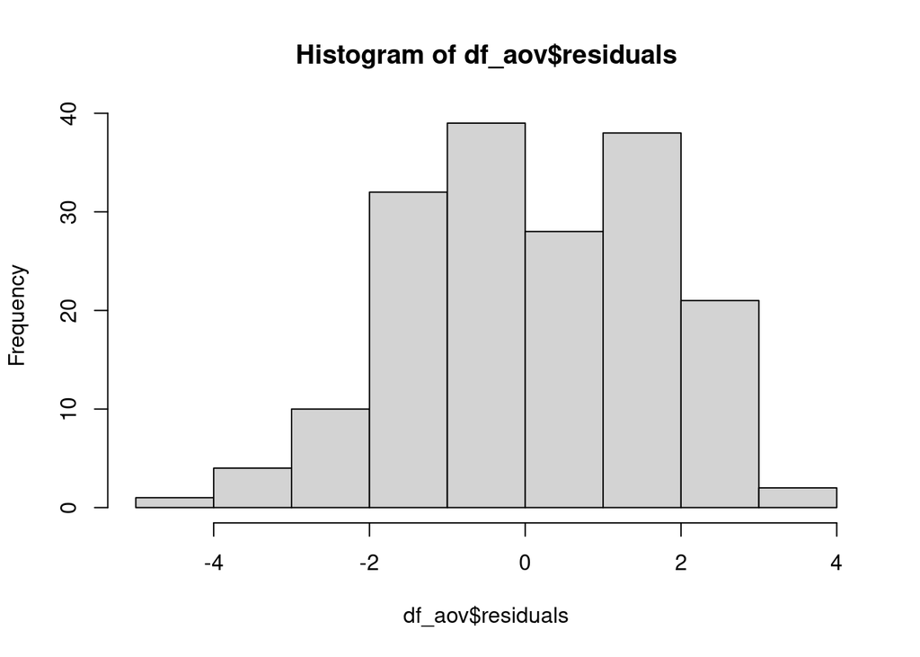

```r
hist(df_aov$residuals)
```

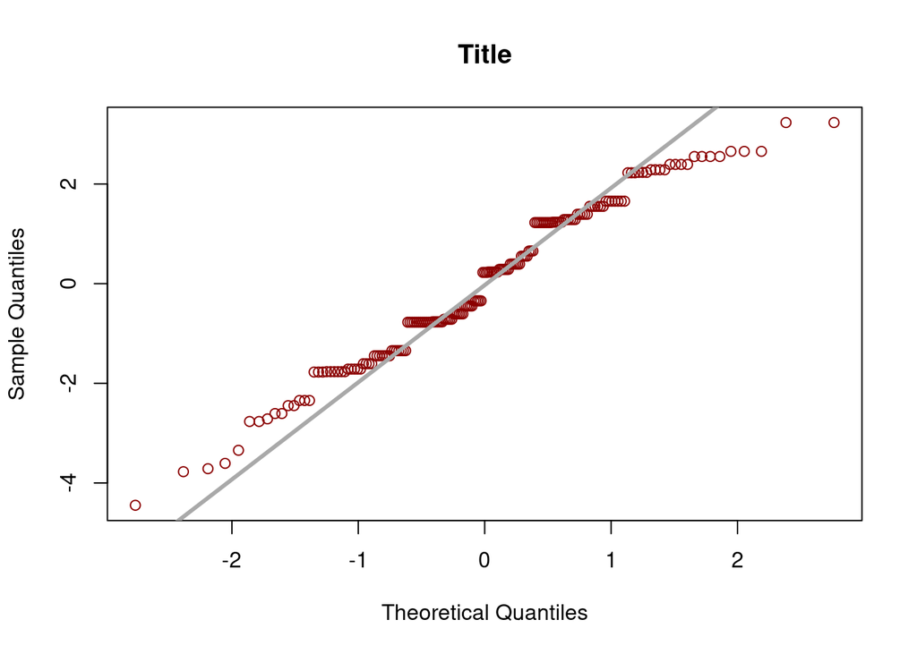

```r
qqnorm(df_aov$residuals, col = "darkred", main = "Title")
qqline(df_aov$residuals, col = "darkgrey", lwd = 3)
```

```r
oneway.test(total_score ~ condition,
            data = df,
            var.equal = FALSE)
```

```
##
##  One-way analysis of means (not assuming equal variances)
##
## data:  total_score and condition
## F = 1.4969, num df = 5.000, denom df = 78.492, p-value = 0.2004
```

```r
oneway.test(total_score ~ L1,
            data = df,
            var.equal = FALSE)
```

```
##
##  One-way analysis of means (not assuming equal variances)
##
## data:  total_score and L1
## F = 1.0653, num df = 1.00, denom df = 172.87, p-value = 0.3034
```

### Compare Synthesis Annotations to Original

```r
df_comparison %>%
  group_by(condition) %>%
  summarise(total_dur_pints = sum(dur),
            total_dur_speaking = sum(unique(filedur)),
            prop = total_dur_pints / total_dur_speaking * 100,
            mean_int = mean(mean_intensity),
            sd_int = sd(mean_intensity)) %>%
  ungroup()
```

```
## # A tibble: 2 × 6
##   condition total_dur_pints total_dur_speaking  prop mean_int sd_int
##   <chr>               <dbl>              <dbl> <dbl>    <dbl>  <dbl>
## 1 orig                 314.               761.  41.3     53.9   13.0
## 2 synth                274.               705.  38.8     49.6   18.4
```

```r
df_comparison %>%
  group_by(condition, segment) %>%
  summarise(count = n()) %>%
  ungroup()
```

```
## # A tibble: 14 × 3
##    condition segment count
##    <chr>     <chr>   <int>
##  1 orig      cl         43
##  2 orig      ex         65
##  3 orig      in        234
##  4 orig      o          82
##  5 orig      sil       656
##  6 orig      uh        210
##  7 orig      um         30
##  8 synth     cl         45
##  9 synth     ex          9
## 10 synth     in        232
## 11 synth     o           2
## 12 synth     sil       288
## 13 synth     uh        212
## 14 synth     um         30
```

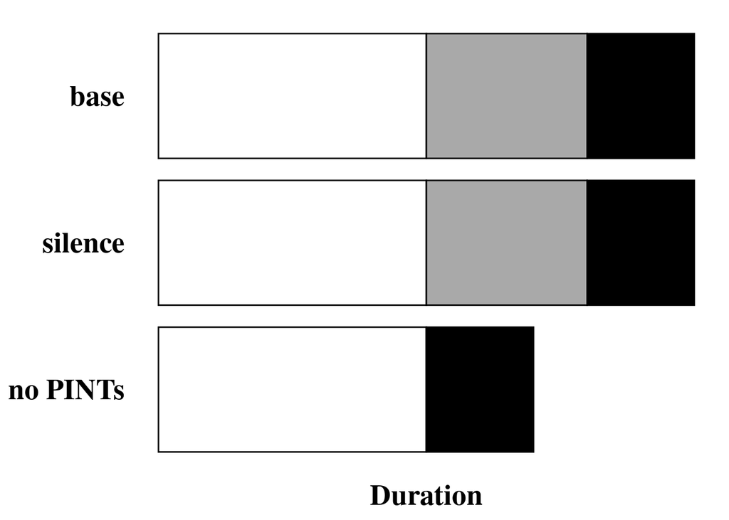

```r
# create dataframe
df_graph <- data.frame(condition = c("base", "silence", "no PINTs"),
                       speech = c(50, 50, 50),
                       PINTs = c(30, 30, 0),
                       answer= c(20, 20, 20))

# Reshape the dataframe from wide to long format using tidyr
df_long <- tidyr::pivot_longer(df_graph, cols = c("speech", "PINTs", "answer"))

# Modify the levels of the "condition" factor to rearrange the bars
df_long$condition <- factor(df_long$condition, levels = c("no PINTs", "silence", "base"))

# create horizontal barplot
ggplot(df_long, aes(x = value, y = condition, fill = name)) +
  geom_bar(stat = "identity", position = "stack", color = "black", width = 0.85) +
  scale_fill_manual(values = c("speech" = "white", "PINTs" = "darkgrey", "answer" = "black")) +
  labs(title = NULL,
       x = "Duration",
       y = NULL,
       fill = NULL) +
  theme_minimal() +
  theme(axis.text.x = element_blank(),
        axis.text.y = element_text(size = 20, face = "bold", family = "Times", color = "black"),
        axis.title = element_text(size = 20, face = "bold", family = "Times", color = "black"),
        legend.position = "none",
        panel.grid.major = element_blank(),
        panel.grid.minor = element_blank())
```